# Re-Discovering Spatial Scan Statistics

Detecting ‘hot spots’ of SIDS cases

R

Anomaly Detection

Author

Gio Circo, Ph.D.

Published

October 24, 2025

## Replicating the NC SIDS Study

### Identifying high clusters

So the basic workflow is as follows:

1. The spatial scan works by passing an ellipse of radius $r$ over each county centroid $c$.
2. For each county $c$ we compute the bernoulli log-likelihood ratio within $r$ to the remainder of the study region.
3. We then repeat steps 1&2 for a fixed value of steps.
4. The primary cluster is the ellipse which maximizes the bernoulli log-likelihood

```r
MIN_ELLIPSE_SIZE = 2e5
MAX_ELLIPSE_SIZE = 1e6
ELLIPSE_NUM_STEPS = 20
ELLIPSE_SIZE_STEPS = round(seq(MIN_ELLIPSE_SIZE, MAX_ELLIPSE_SIZE, length.out = ELLIPSE_NUM_STEPS))
```

The code below performs the loop and adds the results to a dataframe `llr_df`. This will allow us to quickly sort and pull the results.

```r
nc <- nc %>%
  mutate(rate = (SID74 / BIR74) * 1000)

# get county centroids
centroids <- st_centroid(nc)

llr_df <- tibble()

for (j in seq_along(ELLIPSE_SIZE_STEPS)) {
  ellipse_size <- ELLIPSE_SIZE_STEPS[j]

  llr_list <- vector("list", nrow(centroids))

  for (i in seq_len(nrow(centroids))) {
    # 1 choose a single county
    buff <- st_buffer(centroids[i, ], ellipse_size)

    # 2 get all counties within 'buff'
    z <- centroids[buff, ]
    z_idx <- centroids$CNTY_ID %in% z$CNTY_ID
    G <- centroids[!z_idx, ]

    # compute rates
    Z <- compute_rate(z)
    A <- compute_rate(G)

    c <- Z$x
    n <- Z$n
    C <- A$x + c
    N <- A$n + n

    # store county index and log likelihood ratio
    llr_df <- bind_rows(
      llr_df,
      tibble(
        idx = i,
        llr = bernoulli_llr(c, n, C, N),
        idx_ellipse_size = as.character(j),
        cases = c,
        births = n
      ),
    )
  }
}
```

After running this we have a fully populated dataframe containing the bernoulli log-likelihood for each potential cluster centroid, the size of the ellipse around that centroid, and the number of births and deaths in that cluster. For example the output looks something like this:

```
# A tibble: 6 × 5
    idx   llr idx_ellipse_size cases births
  <int> <dbl> <chr>            <dbl>  <dbl>
1     1 0     1                   20  12632
2     2 0     1                   18  12590
3     3 0     1                   43  28631
4     4 0     1                   11   5624
5     5 2.22  1                   39  13882
6     6 0.925 1                   34  13541
```

To identify the primary cluster we just need to select the maximum log-likelihood:

```r
# get the most likely cluster & select its buffer
idx_max_llr <- llr_df$idx[llr_df$llr == max(llr_df$llr)]
idx_max_buff <- as.numeric(llr_df$idx_ellipse_size[llr_df$llr == max(llr_df$llr)])
new_buff <- st_buffer(centroids[idx_max_llr, ], ELLIPSE_SIZE_STEPS[idx_max_buff])

# compute the rate
llr_df$rate <- (llr_df$cases / llr_df$births)*1000
```

…and plot it:

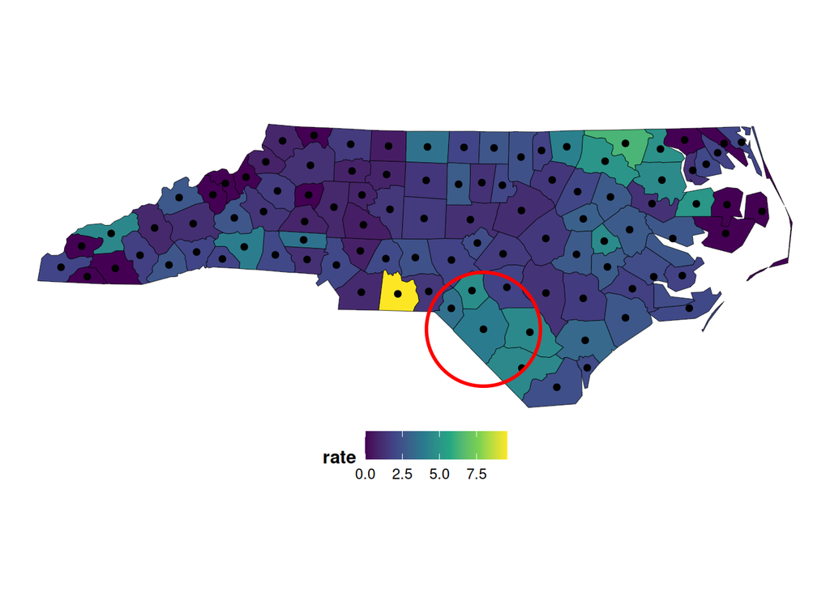

Here we see that the location selected is a cluster of 6 counties centered on Robeson county. This region observed 127 cases of SIDS out of 45,976 live births which is a rate of 2.76 cases per 1,000 births. This is in comparison to the global rate for North Carolina at 2.02 per 1,000. To note - my numbers here don’t line up exactly with the one from Kulldorff’s 1997 paper. I think the sample data I am working with is slightly different. However, more importantly, the primary cluster I identified contains the exact same counties in his paper. So our bit of reverse engineering worked.

Maybe this isn’t the most insightful blog post I’ve ever done, but I always find it useful to dig into old methods and confirm I understand how they actually work. I’ve learned so much more trying to translate the mathematical method into code than just pure reading.